# Default Rates by Demographic Groups

Alexander Turner

## Required Packages

```r
library(dplyr)
library(magrittr)
library(Hmisc)
library(vcd)
```

## Intro

The [data](https://archive.ics.uci.edu/ml/datasets/default+of+credit+card+clients) for this project was obtained from the [UCI Machine Learning Repository](https://archive.ics.uci.edu/ml/index.php). The data contains information relating to Taiwanese bank customers, including certain demographic information and default rates. More info can obtained via the first link. This brief analysis will focus on the relationship between the demographic variables and default rates using data visualisation.

## Data Prep

Some additional data prep was done (factors etc), which is not included here. Also, values “other” were removed from education & marital status variables, due to small sample and lack of information.

```r
# divide age variable into 6 approximate quantiles (data categorisation is needed for the mosaic plots)
default <- default %>%
  mutate(age_bands = cut2(.$AGE, g = 6, minmax = F))

default$age_bands %>% summary()
```

```
## [21,27) [27,31) [31,35) [35,40) [40,46) [46,79]
##    5127    5886    4683    5160    4475    4669
```

```r
# label bands for plotting
default$age_bands <- default$age_bands %>%
  factor(labels = c("21-26", "27-30", "31-34", "35-39", "40-45", "46+"))
```

## (Very) Brief Data Analysis

This part of the analysis involves simply creating proportional tables for each categorical variable and the default rate. This is mainly just as a reference as the plots don’t contain data labels.

```r
# the 2 argument in the prop.table function means proportions are calculated column-wise
table(default$default, default$SEX) %>% prop.table(2) %>% round(2)
```

```
##
##       Male Female
##   No  0.76   0.79
##   Yes 0.24   0.21
```

```r
table(default$default, default$EDUCATION) %>% prop.table(2) %>% round(2)
```

```
##
##       Graduate University High school
##   No      0.81       0.76        0.75
##   Yes     0.19       0.24        0.25
```

```r
table(default$default, default$MARRIAGE) %>% prop.table(2) %>% round(2)
```

```
##
##       Married Single
##   No     0.77   0.79
##   Yes    0.23   0.21
```

```r
table(default$default, default$age_bands) %>% prop.table(2) %>% round(2)
```

```
##
##       21-26 27-30 31-34 35-39 40-45  46+
##   No   0.75  0.80  0.81  0.79  0.78 0.75
##   Yes  0.25  0.20  0.19  0.21  0.22 0.25
```

## Visualisation Code

In each plot the expression `~ variable name + default` means “by variable and default rate” and is a statistical model expression and tells R to plot the conditional proportions. More detail on this follows in the next section.

```r
# create grid with 4 mosaic plots
grid.newpage()
pushViewport(viewport(layout = grid.layout(2, 2)))

# plot 1
pushViewport(viewport(layout.pos.col = 1, layout.pos.row = 1))
mosaic(
  ~ SEX + default,
  data = default,
  labeling_args = list(set_varnames = list(SEX = "Gender", default = "Default")),
  shade = T,
  legend = T,
  newpage = F
)
popViewport()

# plot 2
pushViewport(viewport(layout.pos.col = 2, layout.pos.row = 1))
mosaic(
  ~ EDUCATION + default,
  data = default,
  labeling_args = list(set_varnames = list(EDUCATION = "Education", default = "Default")),
  shade = T,
  legend = T,
  newpage = F
)
popViewport()

# plot 3
pushViewport(viewport(layout.pos.col = 1, layout.pos.row = 2))
mosaic(
  ~ MARRIAGE + default,
  data = default,
  labeling_args = list(set_varnames = list(MARRIAGE = "Marital Status", default = "Default")),
  shade = T,
  legend = T,
  newpage = F
)
popViewport()

# plot 4
pushViewport(viewport(layout.pos.col = 2, layout.pos.row = 2))
mosaic(
  ~ age_bands + default,
  data = default,
  labeling_args = list(set_varnames = list(age_bands = "Age", default = "Default")),
  shade = T,
  legend = T,
  newpage = F
)
popViewport()
```

## Visualisation & Interpretation

The mosaic plots produced by the vcd package are very information-rich.

For each plot (from left to right, top to bottom) the x-axis represents the [conditional probability](https://en.wikipedia.org/wiki/Conditional_probability) of defaulting for each demographic variable:

- $Pr(Default|Male)$, $Pr(Default|Female)$ (the probability of defaulting given gender is known)
- $Pr(Default|High School)$, $Pr(Default|University)$, $Pr(Default|Graduate)$ (the probability of defaulting given education level is known)
- $Pr(Default|Single)$, $Pr(Default|Married)$ (the probability of defaulting given marital status is known)
- $Pr(Default|21-26)$, $Pr(Default|27-30) ...$ (the probability of defaulting given age band is known)

The Pearson residuals show the results from the [Chi-squared test of association](https://en.wikipedia.org/wiki/Chi-squared_test). Blue indicates over-representation and red under-representation. The p-values for the test are also shown and, in this case, are all <.0001. For all 4 variables, there is a statistically significant association with default rate. At a glance, we can see people with a post-graduate education are less likely to default on a loan than someone with only a high school certificate.

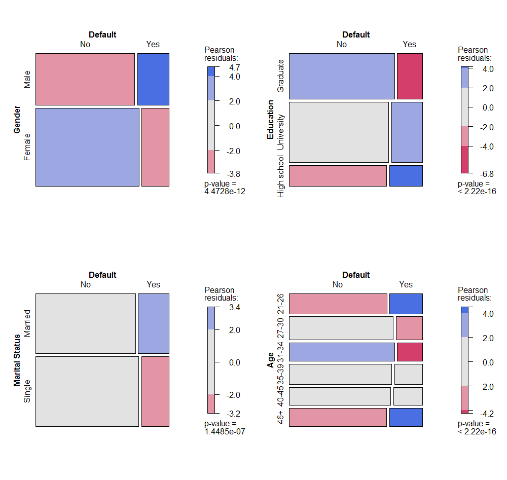